# FigureYa218Elasticnet

小丫画图出品

2021-1-29

欢迎关注“小丫画图”公众号，回复“小白”，看小视频，实现点鼠标跑代码。

小丫微信: epigenomics E-mail: figureya@126.com

作者：大鱼海棠

单位：中国药科大学国家天然药物重点实验室，生物统计与计算药学研究中心、

小丫编辑校验

# 需求描述

我想众筹弹性网络筛选和分类的数据分析。根据表达矩阵，绘制figure2的A,B,C筛选和系数图，再根据结果绘制分类效果E图，得到准确率。

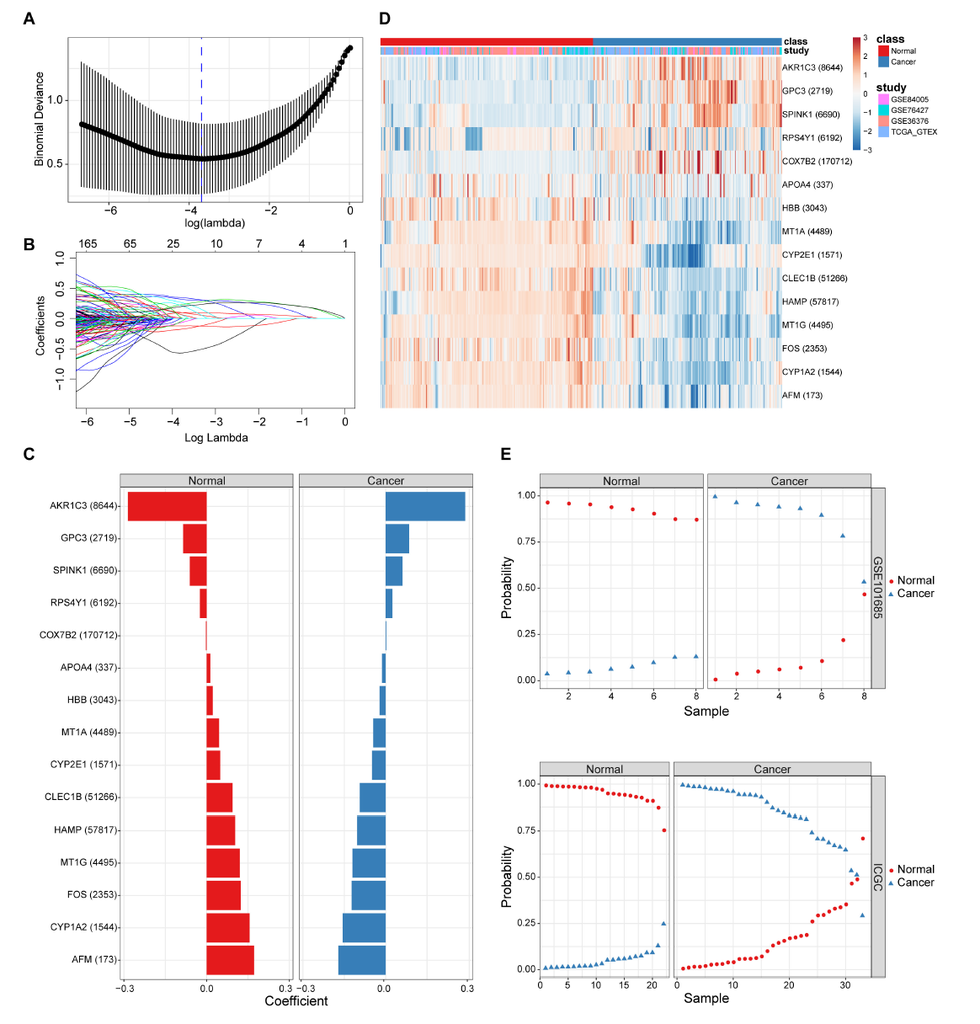

出自https://www.frontiersin.org/articles/10.3389/fgene.2020.00857/full

FIGURE 2 | The screening and validation of 15 genes conducted by the diagnostic classifier. (A,B) Binomial deviance as a function of the regularization parameter lambda for leave-one-study-out cross-validation on the training datasets. Points correspond to the means, and error bars correspond to the standard deviations. Coefficients of 15 genes were selected by the lambda with the minimum binomial deviance marked by the blue dashed line (lambda = 0.025, ln(lambda) = −3.692). (C) Coefficient values for each of the fifteen selected genes. A positive coefficient for a gene signature within its class indicates that elevated expression of this gene increases the probability of a specimen belonging to its tissue type. (D) Heatmap for describing the expression levels of selected genes in the binomial classifier erected by training datasets. Each row is a gene with its Entrez Gene ID in parentheses; each column is a sample. (E) Estimated probabilities for samples in testing datasets (GSE101685 and ICGC). For each sample, there are two points, corresponding to the probability that the sample belongs to the respective class. Within each dataset and class, samples are sorted by the probability of the true class. For most samples, the probability of the true subtype is near 1, indicating an unambiguous classification.

# 应用场景

根据弹性网络筛选变量构建分类模型，生成筛选和系数图，以及分类效果图。

更多机器学习相关FigureYa看这里https://k.koudai.com/ZkmRxldV

# 环境设置

使用国内镜像安装包

```r
options("repos"= c(CRAN="https://mirrors.tuna.tsinghua.edu.cn/CRAN/"))
options(BioC_mirror="http://mirrors.tuna.tsinghua.edu.cn/bioconductor/")
```

加载包

```r
library(data.table)
library(glmnet)
```

```r
library(limma)
library(ggplot2)
Sys.setenv(LANGUAGE = "en") #显示英文报错信息
options(stringsAsFactors = FALSE) #禁止chr转成factor
```

# 输入文件的获得

请到微云下载大文件https://share.weiyun.com/HHLSNqoC

提取感兴趣的肿瘤及对照组织的表达数据。如果你已经准备好，就跳过这步，直接进入“输入文件”。

这里用TCGA的肿瘤，用GTEX的正常组织作为对照。从UCSC xenahttps://xenabrowser.net/datapages/下载经过TOIL流程统一处理的TCGA和GTEx的TPM值，free of computational batch effects。从中提取肝癌和肝脏数据。

- TCGA与GTEX合并的表达数据：https://xenabrowser.net/datapages/?dataset=TcgaTargetGtex_rsem_gene_tpm&host=https%3A%2F%2Ftoil.xenahubs.net&removeHub=https%3A%2F%2Fxena.treehouse.gi.ucsc.edu%3A443
- 样本注释信息：https://xenabrowser.net/datapages/?dataset=TcgaTargetGTEX_phenotype.txt&host=https%3A%2F%2Ftoil.xenahubs.net&removeHub=https%3A%2F%2Fxena.treehouse.gi.ucsc.edu%3A443

我们在FigureYa55panCancer_violin有过类似的操作https://www.yuque.com/figureya/figureyaplus/figureya55p。更多pancancer相关FigureYa看这里https://k.koudai.com/C8RkTgR3

```r
# 加载基因注释文件XENA网站
Ginfo <- read.table("overlapTable27.txt",sep = "\t",row.names = 1,check.names = F,stringsAsFactors = F,header = T)

phenotype <- read.table("TcgaTargetGTEX_phenotype.txt",sep = "\t",row.names = 1,check.names = F,stringsAsFactors = F,header = T)
phenotype <- phenotype[which(phenotype$`_study` %in% c("TCGA","GTEX")),] # filter out TCGA and GETX only, remove TARGET
phenotype <- phenotype[which(phenotype$`_primary_site` != ""),] # remove site with empty value

# 以下数据（9个G）提取过程需要内存较大的电脑（纯R，不受操作系统限制）
# 或者用cut命令提取（需Linux或MAC），可参考FigureYa56immune_inflitration
tpm <- fread("TcgaTargetGtex_rsem_gene_tpm",sep = "\t",header = T,check.names = F,stringsAsFactors = F)
tpm.df <- as.data.frame(tpm)
ensembl <- sapply(strsplit(tpm$sample,".",fixed = T),"[",1) # 取出有效的Ensembl ID

# 过滤出感兴趣的数据集
sites <- unique(phenotype$`_primary_site`) # 提出所有有效的位点
sites # 查看位点
tissue <- "Liver" # 设置位点（必须为有效位点）
if(!is.element(tissue, sites)) { # 如不存在则报错
  stop("incorrect tissue, should be one of the primary_site column in phenotype.txt file.")
}

phenotype_tissue <- phenotype[which(phenotype$`_primary_site` == tissue),]
if(length(unique(phenotype_tissue$`_study`)) == 2) { # 必须同时含有TCGA和GETX数据
  tcga.barcode <- intersect(rownames(phenotype_tissue[which(phenotype_tissue$`_study` == "TCGA"),]), colnames(tpm.df)) # get TCGA samples
  gtex.barcode <- intersect(rownames(phenotype_tissue[which(phenotype_tissue$`_study` == "GTEX"),]), colnames(tpm.df)) # get GTEX samples

  combined.tpm <- tpm.df[,c(tcga.barcode,gtex.barcode)]
  combined.tpm <- 2^(combined.tpm) - 0.001 # 官网数据为log2(x+0.001)转换的，这里转回来
  combined.tpm[combined.tpm < 0] <- 0 # 由于原数据是+0.001来的，所以这里所有<0的数据均为最小值，拉为0
  combined.tpm <- log2(combined.tpm + 1) # 重新对数化，保证0还是0
  rownames(combined.tpm) <- ensembl # 添上行名

  comgene <- intersect(rownames(combined.tpm), rownames(Ginfo)) # 取出和注释文件一致的基因

  # 将Ensembl ID转为symbol
  combined.tpm <- combined.tpm[comgene,]
  combined.tpm$genename <- Ginfo[comgene,"genename"]
  combined.tpm <- combined.tpm[!duplicated(combined.tpm$genename),] # 去除重复基因
  rownames(combined.tpm) <- combined.tpm$genename
  combined.tpm <- combined.tpm[,-ncol(combined.tpm)]
} else {
  stop("this tissue has only one of TCGA or GTEX data, please switch to another tissue.") # 若缺少任何一个数据库，则报错
}
# 保存数据
write.table(combined.tpm,paste0("tpms_",tissue,"_TCGAGTEX.txt"),sep = "\t",row.names = T,col.names = NA,quote = F)
```

# 输入文件

- 训练集：
  - tpms_Liver_TCGAGTEX.txt，TCGA（肝癌）和GTEX（正常组织）表达矩阵。文件太大，在微云上https://share.weiyun.com/HHLSNqoC
  - lihc_sinfo.txt，TCGA肝癌临床信息
- 测试集（GEO数据的下载及数据预处理可参考FigureYa203ComBat）
  - gse101685.expr.txt，表达矩阵
  - gse101685.sinfo.txt，样本信息

加载数据，构建训练集和测试集，并定义早期肝癌与正常组织。

```r
## 训练集
# 加载TCGA_GTEX肝癌表达谱数据
tcga.expr <- read.table("tpms_Liver_TCGAGTEX.txt",sep = "\t",row.names = 1,check.names = F,stringsAsFactors = F,header = T)
tcga.index <- grep("TCGA",colnames(tcga.expr)) # 找到TCGA肝癌样本的索引
tcga.barcode <- colnames(tcga.expr)[tcga.index] # 取出样本名
tcga.barcode <- paste0("LIHC",substr(tcga.barcode,8,15),"A") # 修改样本名以匹配注释文件
colnames(tcga.expr)[tcga.index] <- tcga.barcode # 替换样本名

# 加载TCGA肝癌临床信息
tcga.sinfo <- read.table("lihc_sinfo.txt",sep = "\t",row.names = 1,check.names = F,stringsAsFactors = F,header = T)
tcga.tumsam <- intersect(rownames(tcga.sinfo[which(tcga.sinfo$sampleType == "Tumor" & tcga.sinfo$AJCC_PATHOLOGIC_TUMOR_STAGE == "Stage I"),]), tcga.barcode)
tcga.norsam <- intersect(rownames(tcga.sinfo[which(tcga.sinfo$sampleType == "Normal"),]),tcga.barcode)
gtex.norsam <- colnames(tcga.expr)[grep("GTEX",colnames(tcga.expr))] # 找到GTEX正常样本

# 构建TCGAGTEX最终表达谱以及样本信息
tcga.expr <- tcga.expr[,c(tcga.tumsam,tcga.norsam,gtex.norsam)]
tcga.expr <- tcga.expr[rowSums(tcga.expr) > 0,]
#rownames(tcga.expr) <- gsub("-","_",rownames(tcga.expr),fixed = T)
tcga.sinfo <- data.frame(samID = c(tcga.tumsam,tcga.norsam,gtex.norsam),
                         tissue = rep(c("Tumor","Normal"),c(length(tcga.tumsam), length(tcga.norsam) + length(gtex.norsam))),
                         row.names = c(tcga.tumsam,tcga.norsam,gtex.norsam),
                         stringsAsFactors = F)

## 测试集
gse101685.expr <- read.delim("gse101685.expr.txt",sep = "\t",row.names = 1,check.names = F,stringsAsFactors = F,header = T)
gse101685.expr[1:6,1:3] # 注意到行名里存在多种匹配，取///符号前的基因名（可以在EXCEL里检查一下，但不要用EXCEL进行任何操作，千万不要保存，否则可能出现月份）
```

```
##                           GSM2711996 GSM2711997 GSM2711998
## DHDH                        3.696413   4.405888   4.646549
## T                           5.796679   5.616326   6.240313
## DHFR                        7.632835   7.450049   6.514429
## LEFTY1 /// LEFTY2           4.056968   3.937898   4.354988
## KRTAP4-6 /// LOC101930568   3.320200   3.463535   4.033389
## DHPS                        7.000308   7.225908   6.176475
```

```r
gse101685.expr$Gene <- sapply(strsplit(rownames(gse101685.expr)," /// ",fixed = T),"[",1)
gse101685.expr <- apply(gse101685.expr[,setdiff(colnames(gse101685.expr), "Gene")], 2, function(x) tapply(x, INDEX=factor(gse101685.expr$Gene), FUN=median, na.rm=TRUE))
gse101685.expr <- as.data.frame(round(gse101685.expr,2))
write.csv(gse101685.expr, "easy_input_GSE101685.csv", quote = F)
#rownames(gse101685.expr) <- gsub("-","_",rownames(gse101685.expr),fixed = T)

gse101685.sinfo <- read.delim("gse101685.sinfo.txt",sep = "\t",row.names = 1,check.names = F,stringsAsFactors = F,header = T)
gse.tumsam <- intersect(rownames(gse101685.sinfo[which(gse101685.sinfo$`1:TISSUE` == "Hepatocellular carcinoma" & gse101685.sinfo$`1:STAGE` == "T1"),]),colnames(gse101685.expr)) # 取出肝癌且早期的样本
gse.norsam <- intersect(rownames(gse101685.sinfo[which(gse101685.sinfo$`1:TISSUE` == "Normal liver"),]),colnames(gse101685.expr)) # 取出正常样本

# 构建GSE最终表达谱以及样本信息
gse.expr <- gse101685.expr[,c(gse.tumsam,gse.norsam)]
gse.sinfo <- data.frame(samID = c(gse.tumsam,gse.norsam),
                        tissue = rep(c("Tumor","Normal"),c(length(gse.tumsam),length(gse.norsam))),
                        row.names = c(gse.tumsam,gse.norsam),
                        stringsAsFactors = F)
```

# 构建弹性网络预测模型，查看效果

根据弹性网络筛选变量构建分类模型。

在训练集构建弹性网络预测模型，分别查看模型在训练集和测试集的效果。

```r
# 选取共同基因
comgene <- intersect(rownames(tcga.expr),rownames(gse.expr))

# 先挑选一部分差异表达基因来构建模型
pd <- data.frame(Samples = tcga.sinfo$samID,
                 Group = tcga.sinfo$tissue,
                 stringsAsFactors = FALSE)
design <-model.matrix(~ -1 + factor(pd$Group, levels = c("Tumor","Normal")))
colnames(design) <- c("Tumor","Normal")
gset <- tcga.expr[comgene,pd$Samples]
fit <- limma::lmFit(gset, design = design);
contrastsMatrix <- limma::makeContrasts(Tumor - Normal, levels = c("Tumor", "Normal"))
fit2 <- limma::contrasts.fit(fit, contrasts = contrastsMatrix)
fit2 <- limma::eBayes(fit2, 0.01)
resData <- limma::topTable(fit2, adjust = "fdr", sort.by = "B", number = 100000)
resData <- as.data.frame(subset(resData, select=c("logFC","t","B","P.Value","adj.P.Val")))
resData$id <- rownames(resData)
colnames(resData) <- c("log2fc","t","B","pvalue","padj","id")
resData$fc <- 2^resData$log2fc
resData <- resData[order(resData$padj),c("id","fc","log2fc","pvalue","padj")]
write.table(resData,"limma results between early liver cancer and normal tissues.txt",sep = "\t",row.names = F,col.names = T,quote = F)

# 训练弹性网络
degs <- resData[which(abs(resData$log2fc) > log2(1.5) & resData$padj < 0.05),] # 取出差异表达基因
x <- scale(t(tcga.expr[rownames(degs),rownames(tcga.sinfo)])) # 数据标准化
y <- as.factor(ifelse(tcga.sinfo$tissue == "Tumor",1,0))
set.seed(20201104) # 设置种子使得结果可重复
cvfit <- cv.glmnet(x, y,
                   nfolds = nrow(x), # 余一交叉验证
                   family = "binomial", # 二分类模型
                   grouped = FALSE, # 在余一交叉验证的时候设置为FALSE
                   alpha = 0.9, # 原文参数（alpha=0为岭回归；=1为lasso；=0~1为弹性网络）
                   type.measure = "deviance") # 原文参数

# 取出系数不为0的变量
myCoefs <- coef(cvfit, s="lambda.min");
lasso_fea <- rownames(coef(cvfit, s = 'lambda.min'))[coef(cvfit, s = 'lambda.min')[,1]!= 0]
if(is.element("(Intercept)", lasso_fea)) {
  lasso_fea <- lasso_fea[-1] # 去掉截距项
}

# 查看模型在训练集的效果
pred_train <- data.frame(prob = round(predict(cvfit, newx = x,type="response"),4)[,1],
                         tissue = tcga.sinfo$tissue)

# 查看模型在测试集的效果
x <- as.matrix(as.data.frame(scale(t(gse.expr[rownames(degs),gse.sinfo$samID]))))
pred_test <- data.frame(prob = round(predict(cvfit, newx = x,type="response"),4)[,1],
                        tissue = gse.sinfo$tissue)
```

# 开始画图

生成筛选和系数图，以及分类效果图。

```r
# Figure 2A
pdf("Figure2A.pdf",width = 4.5,height = 4)
par(bty="o", mgp = c(2,0.5,0), mar = c(3.1,3.1,2.1,2.1),tcl=-.25,las = 1)
plot(cvfit)
dev.off()
```

[figure not shown]

```r
# Figure 2B
pdf("Figure2B.pdf",width = 4.5,height = 4)
par(bty="o", mgp = c(2,0.5,0), mar = c(3.1,3.1,2.1,2.1),tcl=-.25,las = 1)
plot(cvfit$glmnet.fit, "lambda", label=FALSE)
dev.off()
```

[figure not shown]

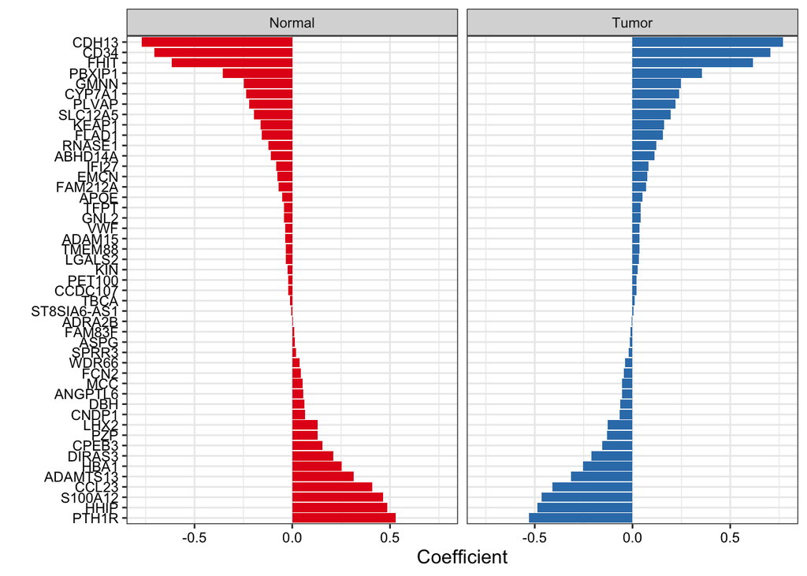

```r
# Figure 2C
coeff <- myCoefs@x[-1]; names(coeff) <- lasso_fea
coeff <- sort(coeff,decreasing = F)
coeff.dt <- data.frame(gene = rep(names(coeff),2),
                    coeff = c(as.numeric(coeff),-as.numeric(coeff)),
                    tissue = rep(c("Tumor","Normal"),c(length(coeff),length(coeff))))
coeff.dt$gene <- factor(coeff.dt$gene, levels = names(coeff))
p <- ggplot(data=coeff.dt, aes(x=gene, y=coeff,fill = tissue)) +
  geom_bar(stat="identity") +
  scale_fill_manual(values = c("#E4191B","#357EB8")) +
  coord_flip() +
  facet_grid( ~ tissue) +
  theme_bw() +
  ylab("Coefficient") + xlab("") +
  theme(legend.position = "none",
        axis.title = element_text(size = 12,color = "black"),
        axis.text = element_text(color = "black"))
p
```

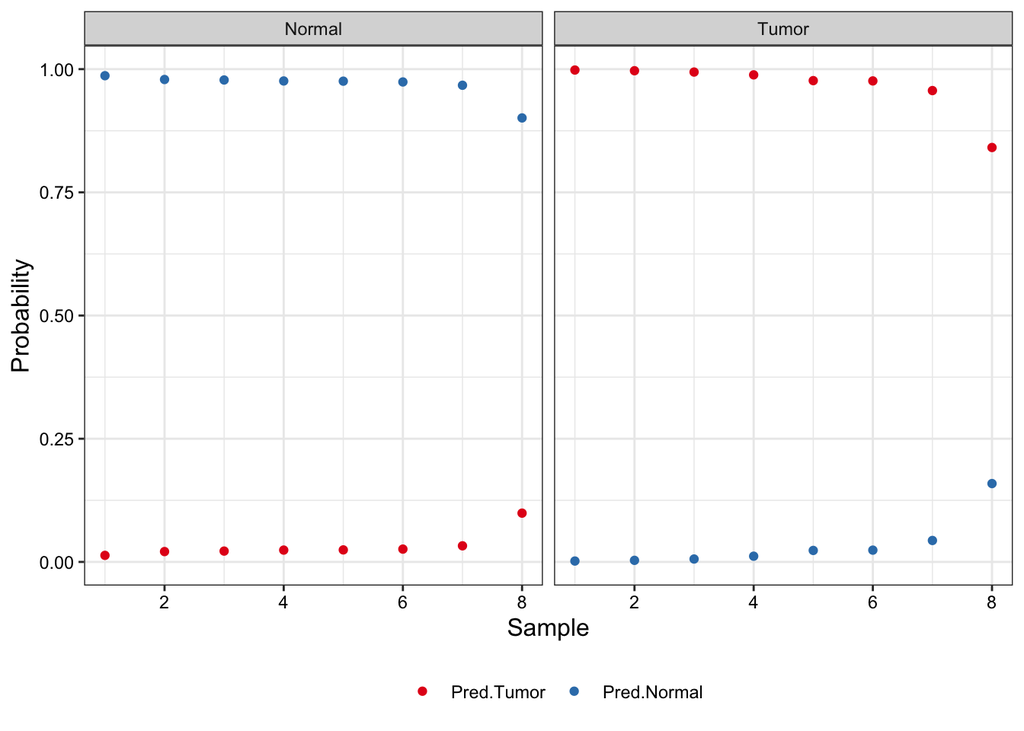

```r
ggsave(file = "Figure2C.pdf",width = 8,height = 6)

# Figure 2E
tmp1 <- pred_test[which(pred_test$tissue == "Tumor"),]
tmp2 <- pred_test[which(pred_test$tissue == "Normal"),]
tmp1 <- tmp1[order(tmp1$prob,decreasing = T),] # 肿瘤概率降序
tmp2 <- tmp2[order(tmp2$prob,decreasing = F),] # 正常概率升序

pred.dt <- rbind.data.frame(tmp1,tmp2)
pred.dt$Pred.Tumor <- pred.dt$prob
pred.dt$Pred.Normal <- 1-pred.dt$prob
pred.dt$sample <- c(1:length(gse.tumsam), 1:length(gse.norsam))
long <- melt(setDT(pred.dt[,2:5]), id.vars = c("tissue","sample"), variable.name = "pred")

p <- ggplot(data=long, aes(x=sample, y=value,color = pred)) +
  geom_point(stat="identity") +
  scale_color_manual(values = c("#E4191B","#357EB8")) +
  facet_grid( ~ tissue) +
  theme_bw() +
  ylab("Probability") + xlab("Sample") +
  theme(legend.position = "bottom",
        legend.title = element_blank(),
        axis.text = element_text(colour = "black"),
        axis.title = element_text(size = 12,color = "black"))
p
```

```r
ggsave(file = "Figure2E.pdf",width = 6,height = 4)
```